# Tabular data classification

## Getting data

A classification task requires two things a label and the observation corresponding to that label, In this case we will use a dataset with description of different mushrooms, and we will try to classify if they are edible or poisonus

|  | class | cap.shape | cap.surface | cap.color | bruises | odor | gill.attachment | gill.spacing | gill.size | gill.color | stalk.shape | stalk.root | stalk.surface.above.ring | stalk.surface.below.ring | stalk.color.above.ring | stalk.color.below.ring | veil.type | veil.color | ring.number | ring.type | spore.print.color | population | habitat |
| --- | --- | --- | --- | --- | --- | --- | --- | --- | --- | --- | --- | --- | --- | --- | --- | --- | --- | --- | --- | --- | --- | --- | --- |
| 1 | p | x | s | n | t | p | f | c | n | k | e | e | s | s | w | w | p | w | o | p | k | s | u |
| 2 | e | x | s | y | t | a | f | c | b | k | e | c | s | s | w | w | p | w | o | p | n | n | g |
| 3 | e | b | s | w | t | l | f | c | b | n | e | c | s | s | w | w | p | w | o | p | n | n | m |
| 4 | p | x | y | w | t | p | f | c | n | n | e | e | s | s | w | w | p | w | o | p | k | s | u |
| 5 | e | x | s | g | f | n | f | w | b | k | t | e | s | s | w | w | p | w | o | e | n | a | g |
| 6 | e | x | y | y | t | a | f | c | b | n | e | c | s | s | w | w | p | w | o | p | k | n | g |

```r
summary(mushrooms)
```

```
 class    cap.shape cap.surface   cap.color    bruises       odor      gill.attachment gill.spacing gill.size
 e:4208   b: 452    f:2320      n      :2284   f:4748   n      :3528   a: 210          c:6812       b:5612
 p:3916   c:   4    g:   4      g      :1840   t:3376   f      :2160   f:7914          w:1312       n:2512
          f:3152    s:2556      e      :1500            s      : 576
          k: 828    y:3244      y      :1072            y      : 576
          s:  32                w      :1040            a      : 400
          x:3656                b      : 168            l      : 400
                                (Other): 220            (Other): 484
   gill.color   stalk.shape stalk.root stalk.surface.above.ring stalk.surface.below.ring stalk.color.above.ring
 b      :1728   e:3516      ?:2480     f: 552                   f: 600                   w      :4464
 p      :1492   t:4608      b:3776     k:2372                   k:2304                   p      :1872
 w      :1202               c: 556     s:5176                   s:4936                   g      : 576
 n      :1048               e:1120     y:  24                   y: 284                   n      : 448
 g      : 752               r: 192                                                       b      : 432
 h      : 732                                                                            o      : 192
 (Other):1170                                                                            (Other): 140
 stalk.color.below.ring veil.type veil.color ring.number ring.type spore.print.color population habitat
 w      :4384           p:8124    n:  96     n:  36      e:2776    w      :2388      a: 384     d:3148
 p      :1872                     o:  96     o:7488      f:  48    n      :1968      c: 340     g:2148
 g      : 576                     w:7924     t: 600      l:1296    k      :1872      n: 400     l: 832
 n      : 512                     y:   8                 n:  36    h      :1632      s:1248     m: 292
 b      : 432                                            p:3968    r      :  72      v:4040     p:1144
 o      : 192                                                      b      :  48      y:1712     u: 368
 (Other): 156                                                      (Other): 144                 w: 192
```

```r
table(mushrooms$class)
```

```
   e    p
4208 3916
```

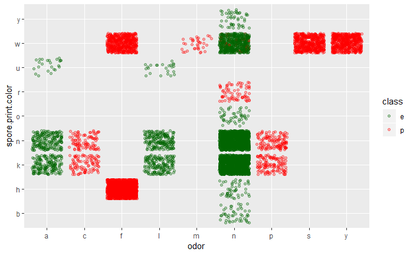

```r
library(ggplot2)
p = ggplot(mushrooms,aes(x=odor,
                    y=spore.print.color,
                    color=class))
p + geom_jitter(alpha=0.3) +
  scale_color_manual(breaks = c('e','p'),
                     values=c('darkgreen','red'))
```

In this case: odor (almond=a,anise=l,creosote=c,fishy=y,foul=f,musty=m,none=n,pungent=p,spicy=s) spore-print-color(black=k,brown=n,buff=b,chocolate=h,green=r,orange=o,purple=u,white=w,yellow=y)

Data seems like there is enough difference between the observersion of edible mushrooms and poisonus, let’s prepare the data for classification

```r
library(randomForest)
```

Let’s look at the class balance for the training set

```r
table(mush.train$class)/nrow(mush.train)
```

```
        e         p
0.6400191 0.3599809
```

And now for the original dataset

```r
table(mushrooms$class)/nrow(mushrooms)
```

[output not shown]

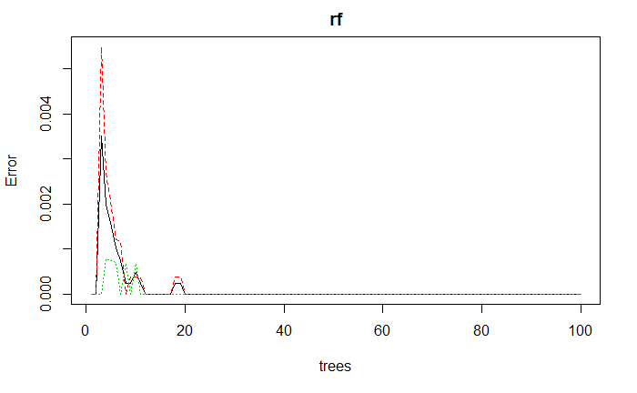

Now let’s check what are the more important variables

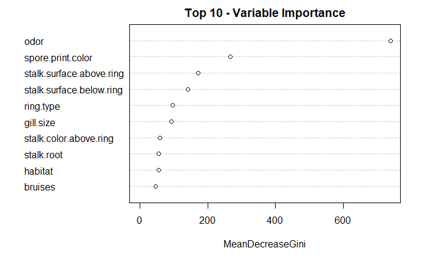

Now lets evaluate our model

```r
confusionMatrix(table(predicted=mpred,actual=mush.test$class), mode = "everything")
```

```
Confusion Matrix and Statistics

         actual
predicted   e   p
        e 892   0
        p   0 502

               Accuracy : 1
                 95% CI : (0.9974, 1)
    No Information Rate : 0.6399
    P-Value [Acc > NIR] : < 2.2e-16

                  Kappa : 1
 Mcnemar's Test P-Value : NA

            Sensitivity : 1.0000
            Specificity : 1.0000
         Pos Pred Value : 1.0000
         Neg Pred Value : 1.0000
              Precision : 1.0000
                 Recall : 1.0000
                     F1 : 1.0000
             Prevalence : 0.6399
         Detection Rate : 0.6399
   Detection Prevalence : 0.6399
      Balanced Accuracy : 1.0000

       'Positive' Class : e
```